# Datavisualisering

## Facets eksempel

**Q42: Ligestilling**<sup>1</sup> vs. **Q17: Partivalg**<sup>2</sup>

**Kode**

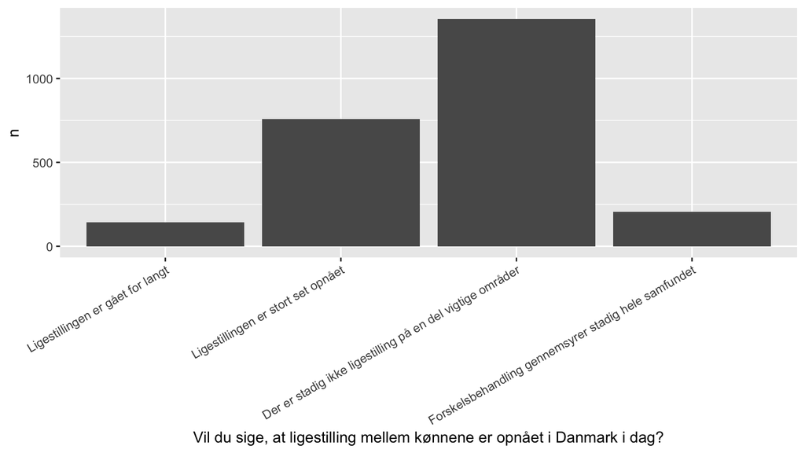

```r
vu |>
  filter(Q42 %in% 1:4, Q17 %in% 1:29) |> # Ingen "Ved ikke", kun kendte partier
  count(Q17 = to_factor(Q17), Q42 = to_factor(Q42)) |>
  ggplot() +
  aes(x = Q42, y = n) +
  geom_col() +
  theme(axis.text.x = element_text(angle = 30, hjust = 1))
```

[^6]: Vil du sige, at ligestilling mellem kønnene er opnået i Danmark i dag?
[^7]: Hvilket parti stemte du på ved folketingsvalget den 1. november 2022?

Tilføj: `facet_wrap(~Q17, nrow = 2, scales = "free_y") +`

**Kode**

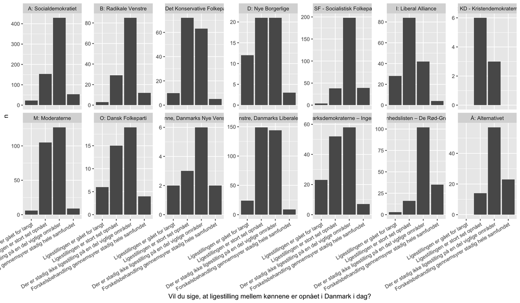

```r
vu |>
  filter(Q42 %in% 1:4, Q17 %in% 1:29) |> # Ingen "Ved ikke" og kun kendte partier
  count(Q17 = to_factor(Q17), Q42 = to_factor(Q42)) |>
  ggplot() +
  aes(x = Q42, y = n) +
  geom_col() +
  facet_wrap(~ Q17, nrow = 2, scales = "free_y") + # OBS! Husk en tilde "~" før variablen
  theme(axis.text.x = element_text(angle = 30, hjust = 1))
```

Tilføj: **fill = gender**

**Kode**

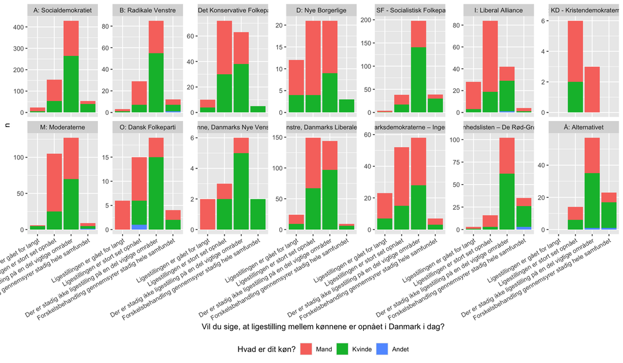

```r
vu |>
  filter(Q42 %in% 1:4, Q17 %in% 1:29) |> # Ingen "Ved ikke" og kun kendte partier
  count(gender = to_factor(gender), Q17 = to_factor(Q17), Q42 = to_factor(Q42)) |>
  ggplot() +
  aes(x = Q42, y = n, fill = gender) +
  geom_col() +
  facet_wrap(~ Q17, nrow = 2, scales = "free_y") + # OBS! Husk en tilde "~" før variablen
  theme(axis.text.x = element_text(angle = 30, hjust = 1),
        legend.position = "bottom")
```

**Hvor mange og hvilke variable er med på plottet? Hvilke 3 forbedringer, ville I lave?**

**Kode**

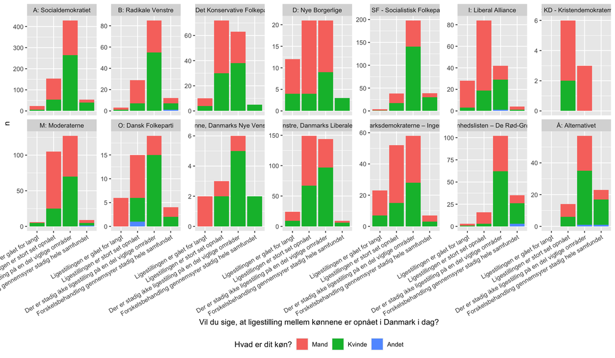

```r
vu |>
  filter(Q42 %in% 1:4, Q17 %in% 1:29) |> # Ingen "Ved ikke" og kun kendte partier
  count(gender = to_factor(gender), Q17 = to_factor(Q17), Q42 = to_factor(Q42)) |>
  ggplot() +
  aes(x = Q42, y = n, fill = gender) +
  geom_col() +
  facet_wrap(~ Q17, nrow = 2, scales = "free_y") + # OBS! Husk en tilde "~" før variablen
  theme(axis.text.x = element_text(angle = 30, hjust = 1),
        legend.position = "bottom")
```

## facet_grid()

- alternativ til `facet_wrap()`
- med `facet_grid()` kan vi facetere på **to variable** (en for rækker, en for kolonner):
- **syntaks**: (p +) `facet_grid(række_var ~ kolonne_var)`

**Kode**

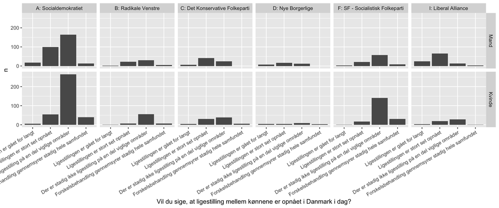

```r
vu |>
  filter(Q42 %in% 1:4, Q17 %in% 1:10, gender %in% 1:2) |> # Ingen "Ved ikke", "Andet", og kun udvalgte partier
  count(gender = to_factor(gender), Q17 = to_factor(Q17), Q42 = to_factor(Q42)) |>
  ggplot() +
  aes(x = Q42, y = n) +
  geom_col() +
  facet_grid(gender ~ Q17) +
  theme(axis.text.x = element_text(angle = 30, hjust = 1),
        legend.position = "bottom")
```

## {patchwork}

- med pakken **{patchwork}** kan vi nemt “manuelt” sætte flere figurer sammen til én
- ikke helt det samme som facets, men lignende resultat og meget fleksibelt
- **syntaks**: `p1 + p2 + p3`
  - mange layout-muligheder

**Kode**

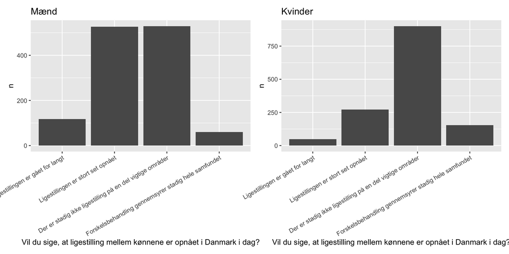

```r
library(patchwork)

p1 <- vu |>
  filter(Q42 %in% 1:4, gender == 1) |> # Ingen "Ved ikke", OBS! kun "Mand"
  count(Q42 = to_factor(Q42)) |>
  ggplot() +
  aes(x = Q42, y = n) +
  geom_col() +
  theme(axis.text.x = element_text(angle = 30, hjust = 1)) +
  labs(title = "Mænd")

p2 <- vu |>
  filter(Q42 %in% 1:4, gender == 2) |> # Ingen "Ved ikke", OBS! kun "Kvinde"
  count(Q42 = to_factor(Q42)) |>
  ggplot() +
  aes(x = Q42, y = n) +
  geom_col() +
  theme(axis.text.x = element_text(angle = 30, hjust = 1)) +
  labs(title = "Kvinder")

p1 + p2
```

## Skalaer og farver

- Alle aesthetics har en (implicit eller explicit) skala
- Justeres med `scale_*`-elementerne
- For **x og y** justerer man ofte intervaller (breaks) og labels
  - kategorisk/binær = `scale_x_discrete()`
  - intervalskaleret = `scale_y_continuous()`
  - ordinal kan være begge
- For **farver, former mv.** kan man vælge, hvilke værdier der får hvilket udseende
  - `scale_color_manual()`
  - `scale_shape_manual()`

## Skalaer og farver

- Farver skal ikke kun være flotte, men også mulige at adskille – fx også for folk med **farveblindhed**
  - generelt er datavisualisering baseret på menneskets **perception** ([Healy 2019](https://socviz.co/); Wickham 2008)
- Der findes **færdiglavede farveskalaer**, fx
  - `scale_color_brewer(type = "qual", palette = 2)`
  - `scale_color_viridis_c()`, `scale_fill_viridis_d()`
- Eller man kan indstille farverne **manuelt**, fx
  - `scale_fill_manual(values = c("blue", "red", "green"))`
  - `scale_color_gradient(low = "blue", high = "red")`
- Man kan altid bruge `*_manual` med **hex color codes**: fx “#123456” (brug online tools)
  - der er også 657 indbyggede, navngivne farver i R, fx ‘mistyrose2’, ‘tomato4’, ‘mintcream’
  - se listen med `colors()`, se en farve med `scales::show_col("tomato4")`

## Skalaer og farver

**Kode**

```r
pcol1 <- mpg_plot1 +
  scale_color_brewer(type = "qual", palette = 8) +
  labs(subtitle = str_wrap('scale_color_brewer(type = "qual", palette = 8)', 35))

pcol2 <- mpg_plot1 +
  scale_color_viridis_d() +
  labs(subtitle = str_wrap("scale_color_viridis_d()", 35))

pcol3 <- mpg_plot1 +
  scale_color_manual(values = c("pink", "#abc500", "seagreen2", "grey65")) +
  labs(subtitle = str_wrap('scale_color_manual(values = c("pink", "#abc500", "seagreen2"))', 35))

pcol1 + pcol2 + pcol3 + plot_layout(nrow = 1) & theme(legend.position = "bottom")
```

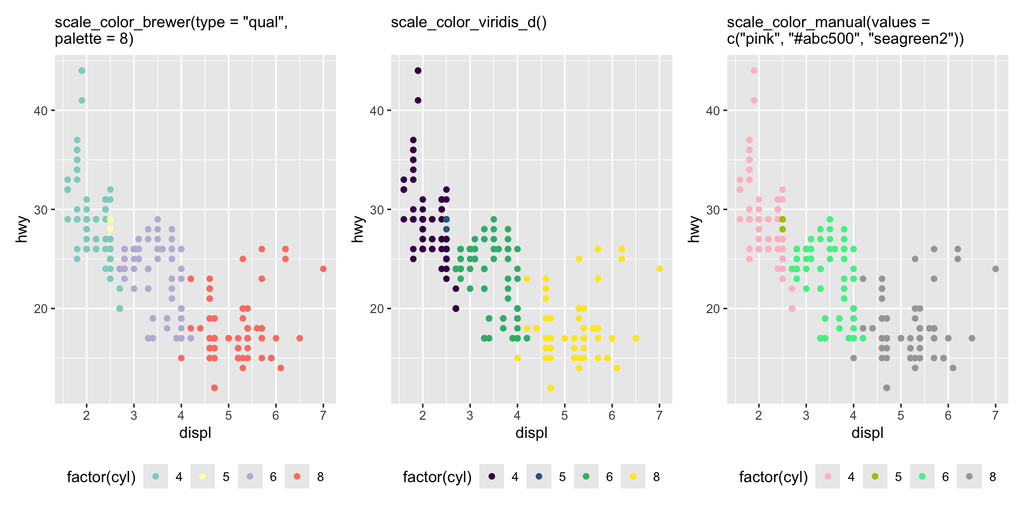

## Labels

**Kode**

```r
p8 +
  labs(title = "Alder på S og V-vælgere",
       subtitle = "Folketingsvalget 2022",
       x = "Alder",
       y = NULL,
       fill = "Partivalg",
       color = "Partivalg",
       caption = "Data: Valgundersøgelsen 2022"
       )
```

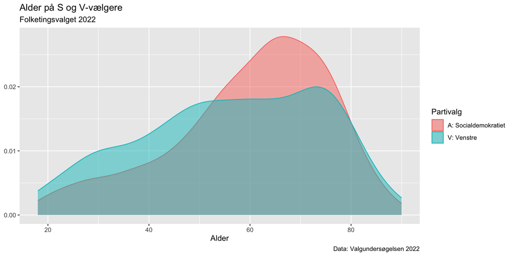